# BigMac Simple Linear Regression

INSOFE

2nd Sep, 2018

```r
# First things first , clean your R environment
rm(list=ls())
```

# *Simple Linear Regression Model*

# Read or load data

```r
dataFile = "BigMac-NetHourlyWage.csv"
BigMac = read.delim(dataFile,sep=",",header=TRUE)
```

# Define the independent and dependent variables

- In Linear Regression, the dependent variable is continuous variable.
- Simple Linear Regression has only one independent variable

```r
names(BigMac)           # Display the column names
```

```
## [1] "Country"              "BigMacPriceDollars"   "NetHourlyWageDollars"
```

```r
xvar = names(BigMac)[2] # BigMacPriceDollars
yvar = names(BigMac)[3] # NetHourlyWageDollars
```

- Summary of the data and look for any missing values:

```r
str(BigMac)        # Structure of the dataset
```

```
## 'data.frame':    27 obs. of  3 variables:
##  $ Country             : Factor w/ 27 levels "Argentina","Australia",..: 1 2 3 4 5 6 7 8 9 10 ...
##  $ BigMacPriceDollars  : num  1.78 3.84 4.91 3.48 4 3.34 1.95 3.43 4.9 3.33 ...
##  $ NetHourlyWageDollars: num  3.3 14 4.3 13.9 12.8 3.1 3 5.1 17.7 3 ...
```

```r
summary(BigMac)    # Summary of the dataset
```

```
##       Country   BigMacPriceDollars NetHourlyWageDollars
##  Argentina: 1   Min.   :1.780      Min.   : 1.300
##  Australia: 1   1st Qu.:2.475      1st Qu.: 3.100
##  Brazil   : 1   Median :3.330      Median : 5.100
##  Britain  : 1   Mean   :3.349      Mean   : 7.726
##  Canada   : 1   3rd Qu.:3.785      3rd Qu.:13.150
##  Chile    : 1   Max.   :6.560      Max.   :22.600
##  (Other)  :21
```

- No missing values

# Plot the dependent and independent variables

- The type of plot used to see the relationship between two continuous variables is called a *Scatter Plot*

[figure not shown]

```r
plot(BigMac$BigMacPriceDollars,BigMac$NetHourlyWageDollars,
      main = "NetHourlyWageDollars vs BigMacPriceDollars",
     ylab = "NetHourlyWageDollars",
     xlab = "BigMacPriceDollars",
     col = "brown",lwd = 2)
```

# Correlation of the variables

- Correlation of two variables gives a very good estimate as to how the two variables change together, this also helps us have an idea as to how well a Linear Regression Model will be able to predict the dependent variable.

```r
cor(BigMac$NetHourlyWageDollars,BigMac$BigMacPriceDollars)
```

```
## [1] 0.717055
```

# Building the Linear Regression Model

- `lm(F=formula, data)` is the funtion syntax in R to build a Linear Regression model

```r
lineFit = lm(NetHourlyWageDollars~BigMacPriceDollars,data=BigMac)
```

## Read the model summary

- Summary displays the following
  - Formula given(Call)
  - 5 point summary for the residuals
  - The coefficients and the test statistic values for them
  - Residual Standard Error
  - Multiple R- Squared ( Which we generally refer to as R squared or Co-efficient of Determination)
  - Test for Model -> F statistic

```r
summary(lineFit)
```

```
##
## Call:
## lm(formula = NetHourlyWageDollars ~ BigMacPriceDollars, data = BigMac)
##
## Residuals:
##     Min      1Q  Median      3Q     Max
## -8.9639 -2.9141 -0.1813  3.2058  7.4221
##
## Coefficients:
##                    Estimate Std. Error t value Pr(>|t|)
## (Intercept)         -4.1540     2.4478  -1.697    0.102
## BigMacPriceDollars   3.5474     0.6897   5.144 2.57e-05 ***
## ---
## Signif. codes:  0 '***' 0.001 '**' 0.01 '*' 0.05 '.' 0.1 ' ' 1
##
## Residual standard error: 4.213 on 25 degrees of freedom
## Multiple R-squared:  0.5142, Adjusted R-squared:  0.4947
## F-statistic: 26.46 on 1 and 25 DF,  p-value: 2.571e-05
```

- Try Answering these questions
  1. Is the slope significant?
  2. Is the Model significant?
  3. What is the predictive power of the model (R-squared)

# Plot the data points and the line of best fit

[figure not shown]

```r
plot(BigMac$BigMacPriceDollars,BigMac$NetHourlyWageDollars, col = "brown",lwd = 2,
     xlab="BigMacPriceDollars",ylab="NetHourlyWageDollars",main="NetHourlyWageDollars vs BigMacPriceDollars: Best fit line")
abline(lineFit,col="blue",lty=1,lwd=2);
grid(10,10,lwd=1)
```

# Residual Analysis

## Plot residuals

- Residual is nothing but the difference between the predicted value and the actual value i.e
  $$y_i-\hat{y}_i$$
- where i is the $i^{th}$ training sample

We can extract the residuals from the linear model and plot them.

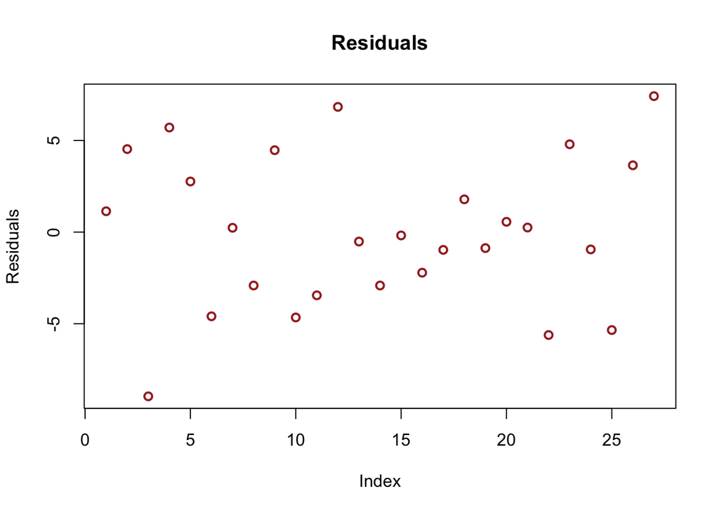

```r
plot(lineFit$residuals,ylab="Residuals",main="Residuals",col = 'brown', lwd = 2)
```

## Plot residuals vs fitted values

- This will help us visualize how the residuls are distrubuted in relation to the fitted values

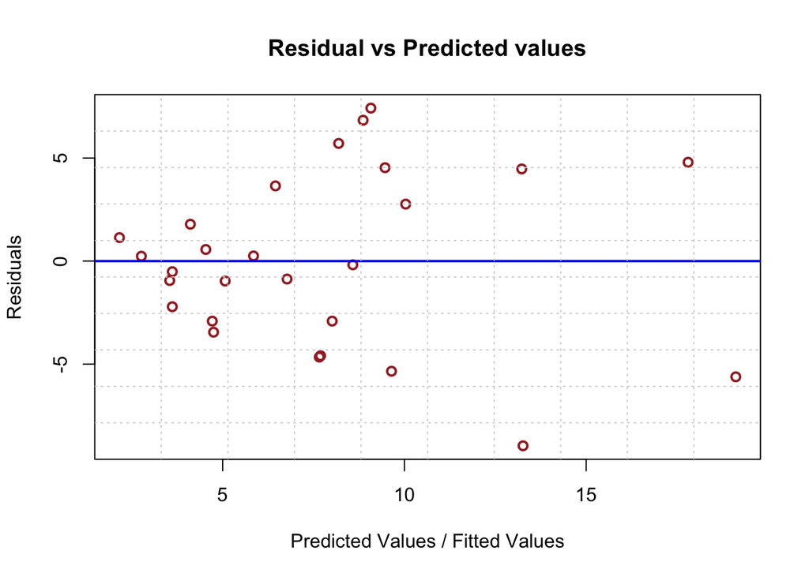

```r
plot(lineFit$fitted.values,lineFit$residuals,main = "Residual vs Predicted values", col = 'brown',lwd = 2,
xlab ="Predicted Values / Fitted Values", ylab = "Residuals")
abline(h = 0,col = 'blue',lwd  =2)
grid(10,10,lwd=1)
```

## Residual plots with R plot function

- In R four diagnostic plots can be obtained by calling the plot function on fitted model obtained using lm

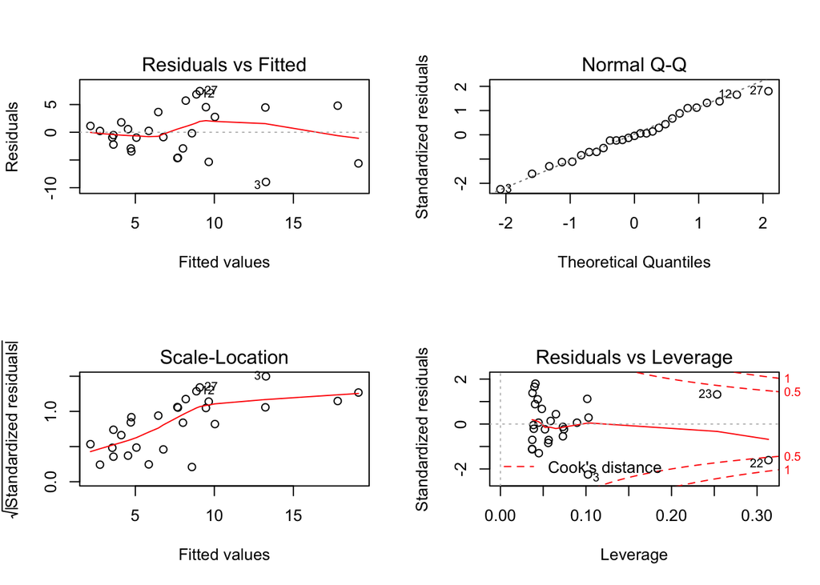

```r
par(mfrow = c(2,2)) # par helps us set graphical parameters, refer to help for more info on this
plot(lineFit)
```